# 1. Въведение в python

## 1.1. Защо python?

- General purpose: python е език за програмиране с широко приложение. С него можем не само да построим един статистически модел, но и да изградим всичката периферна структура, която позволява този модел да бъде използван ан индустриално ниво.
- Performance: модерните компютри са толкова мощни, че в повечето случаи няма особено значение. При работа с огромни масиви от високо размерни данни обаче, вече искаме да използваме възможно най-ефикасно изчислителните си ресурси.

## 1.2. Инсталация и среда за работа

Най-новата версия на **python3** можем да свалим от https://www.python.org/downloads/. За да изполваме python за анализ на данни, е нужно да инсталираме допълнителни библиотеки. Това става с командата `pip` (*ако имаме и старата версия python2 инсталирана на компютъра, трябва да ползваме pip3, за да покажем, че искаме да инсталираме библитеки за python3*).

### 1.2.1. Инсталиране на jupyter

Първата библиотека, която ще инсталираме е `jupyter`. Ще я използваме, за да създаваме jupyter notebooks - това което разглеждаме сега. Те ни позволяват да работим с python интерактивно в браузъра. Това става като отворим терминал и въведем командата:

`pip install jupyter`

Това ще потърси най-новата версия на `jupyter` в [публичния индекс](https://pypi.org/) от библиотеки за python, ще я свали и инсталира. Сега можем да отворим интерфейса на jupyter като въведем командата:

`jupyter notebook`

От тук можем да създадем нов ноутбук:

[figure not shown]

Това ще отвори ноутбука, където сме готови да започнем да пишем python като въведем нещо в клетката и натиснем shift+Enter:

[figure not shown]

## 1.3. Основни концепции

Пълната документация на python можете да намерите [тук](https://docs.python.org/3/index.html). Ако имате някакъв проблем или въпрос и няма кого да питате, най-вероятно някой друг също го е имал преди вас - гугъл и [stack overflow](https://stackoverflow.com/search?q=%5Bpython%5D+isaccepted%3Ayes) са най-добрите ви приятели в този случай.

Както всеки език за програмиране, python има основните концепции като променливи, колекции от данни, if/else проверки, цикли, функции и т.н. Ще се разпознаем накратко с тях:

### 1.3.1. [Променливи](https://docs.python.org/3/library/stdtypes.html)

Можем да декларираме променливи, които сочат към обекти в паметта на компютъра с различни типове. Например, **int** (цяло число), **float** (реално число), **str** (текст), **bool**:

```python
# int
a = 10
print(a)

# float
c = 6.3
print(c)

# str
b = "foo"
print(b)

# bool
d = True
print(d)
print(not d)
```

[output not shown]

python е динамично типизиран език. Това означава, че промеливите нямат статичен тип и можем да ги предефинираме да сочат към друг тип обект:

```python
v = 15
print(v)
v = 'bar'
print(v)
```

```
15
bar
```

Като използваме операторът **=** задачаме нова стойност на промеливата, т.е. сменяме обекта, към които тя сочи:

```python
a = 5
b = a
b = 10
# jupyter автоматично принтира резултатът от кода в клетката.
# Можем просто да кажем една променлива и ще я видим без print
a
```

```
5
```

Виждаме, че `a` остава непроменена, понеже `b = 10` заменя обекта (в този случай число), към които `b` сочи, с друг, а не променя оригиналния обект. Това е доста дълбока тема, неразбирането на която може да доведе до много бъгове, ако пишем по-сложни програми. Засега не би трябвало да имаме такива проблеми.

Можем да проверяваме типа на една променлива като използваме вградената функция isinstance:

```python
isinstance('some text', str)
```

```
True
```

```python
isinstance('some text', float)
```

```
False
```

```python
isinstance(5.2345, float)
```

```
True
```

Можем да преминаваме между различни типове, като извикаме типа като функция:

```python
print(int(5.3456)) # float -> int
print(float(7)) # int -> float
print(str(3.1415)) # float -> str
print(int("124523"))# int -> str
# etc.
```

```
5
7.0
3.1415
124523
```

### 1.3.2. [Числови променливи](https://docs.python.org/3/library/stdtypes.html#numeric-types-int-float-complex)

Между числови промеливи имаме обичайните операции, както и някои вградени функции:

```python
c = a + b
s = a - b
d = a / b
m = a * b
# вдигаме на степен с **
p = b ** 2
# абсолютна стойност
e = abs(-123)

# можем да извършваме операции и да присояваме стойност едновременно с +=, -=, *= и /=
a = 5
a += 2 # еквивалентно на a = a + 2
print(a)
a *= 3 # еквивалентно на a = 3 * a
print(a)
```

```
7
21
```

Деленето на цели числа връща реално число. Ако искаме целочислено делене (делене без остатък), трябва да изпозлваме **//**. Ако искаме делене с остатък, използваме вградената функция **divmod**

```python
print(27 / 5)
print(27 // 5)
print(divmod(27, 5))
```

```
5.4
5
(5, 2)
```

Резултатът от **divmod** е двойка от числа, наречена tuple, която ше разгледаме след малко.

### 1.3.3 Булеви променливи (bool)

Булевите променливи представляват резултатът от логически проверки, които стават с == (равно), != (не равно), <, <=, >, >=.

```python
var = 5
var == 5
```

```
True
```

```python
var !=5
```

```
False
```

```python
var != 7
```

```
True
```

```python
var == '5' # 5 and '5' are not the same type, so they can't be equal
```

```
False
```

```python
var < 10
```

```
True
```

Другите типове могат се използват в логически проверки като имплицитно се превръщат в bool. Във False се превръщат 0 и празния стринг ''

```python
bool(0)
```

```
False
```

```python
bool(1)
```

```
True
```

```python
bool(5)
```

```
True
```

```python
bool('asdf')
```

```
True
```

```python
bool('')
```

```
False
```

Логичските операции "и" и "или" стават просто с английските думи "and" и "or", а отрицанието - с "not".

```python
var == 5 and bool(12)
```

```
True
```

```python
var < 3 or True
```

```
True
```

```python
'test' == 'test' and not var == 5
```

```
False
```

### 1.3.4. [Колекции: list, tuple, set](https://docs.python.org/3/library/stdtypes.html#sequence-types-list-tuple-range)

#### list

Масивите от данни в python се наричат листове. Те се дефинират с квадратни скоби:

```python
arr = [1, 2, 5, 'asdf', 5.3, -12.4]
print(arr)
```

```
[1, 2, 5, 'asdf', 5.3, -12.4]
```

Както виждаме, те могат съдърждат елементи от различни типове. Основните операции върху листове са:

```python
# индексиране (започва от 0!!)
print(arr[0])
print(arr[3])
print(arr[4])

# може и отзад напред. Последния елемент:
print(arr[-1])
```

```
1
asdf
5.3
-12.4
```

```python
# взимане на подлистове (slicing)
print(arr[1:3])
print(arr[2:-2])

# ако първото липсва, е от началото
print(arr[:4])

# ако второто липсва, е до края
print(arr[3:])

# можем и да зададем стъпка, т.е. да прескачаме
print(arr[1:5:2])
```

```
[2, 5]
[5, 'asdf']
[1, 2, 5, 'asdf']
['asdf', 5.3, -12.4]
[2, 'asdf']
```

```python
# промяна на елементи
arr[2] = 'foo'
print(arr)

# добавяне на друг лист
brr = [34, 12.9, 'hello', 1, 2, 3]
crr = arr + brr
print(crr)

# добавяне на един елемент
crr.append('appended')
print(crr)

# премахване на елемент
last_element = crr.pop() # маха последния
third_element = crr.pop(2) # маха елемента на индекс 2 (третия)

print(last_element)
print(third_element)
print(crr)
```

```
[1, 2, 'foo', 'asdf', 5.3, -12.4]
[1, 2, 'foo', 'asdf', 5.3, -12.4, 34, 12.9, 'hello', 1, 2, 3]
[1, 2, 'foo', 'asdf', 5.3, -12.4, 34, 12.9, 'hello', 1, 2, 3, 'appended']
appended
foo
[1, 2, 'asdf', 5.3, -12.4, 34, 12.9, 'hello', 1, 2, 3]
```

#### tuple

tuple-ът е същото като list, но е immutable, т.е. не може да бъде променян, след като е създаден. Дефинира се с кръгли скоби:

```python
tpl = (1, 2, 3)
other_tpl = ('foo', 'hash', 'rag')
print(tpl + other_tpl)
print(tpl[2])

tpl[0] = 'will raise error'
```

```
(1, 2, 3, 'foo', 'hash', 'rag')
3
```

```
---------------------------------------------------------------------------
TypeError                                 Traceback (most recent call last)
<ipython-input-27-c0e4d5ec7966> in <module>
      4 print(tpl[2])
      5
----> 6 tpl[0] = 'will raise error'

TypeError: 'tuple' object does not support item assignment
```

можем да приравним няколко променливи на елементите на tuple, като ги поставим отдясно на равното (tuple unpacking):

```python
t = (12, 435, 'bar')
a, b, c = t
print(a)
print(b)
print(c)

quotient, remainder = divmod(41, 5)
print(quotient)
print(remainder)
```

```
12
435
bar
8
1
```

#### set

set имплементира концепцията за множество. Подобно е на лист, но не е подредено. Използва се когато се интересуваме само дали даден елемент принадлежи на множество, без да се интересуваме от някаква подредба. Проверката дали даден елемент е в лист (ще го видим при **if/else**) става все по-бавна колкото повече елементи има в листа, но при сета не зависи от големината му. За сетове имаме дефинирани основните логически операции между множества.

```python
st = {1, 2, 3, 'ftp', 'nadh+', 'test'}
other_st = {1, 2, 'dasfx', 'test'}

# обединение
print(st | other_st)

# сечение
print(st & other_st)

# разлика
print(st - other_st)

# подмножество
print(other_st < st)
print({1, 'ftp'} < st)
```

```
{1, 2, 3, 'ftp', 'test', 'dasfx', 'nadh+'}
{'test', 1, 2}
{'ftp', 3, 'nadh+'}
False
True
```

### 1.3.5. [Текстови променливи (str)](https://docs.python.org/3/library/stdtypes.html#text-sequence-type-str)

Текстовите променливи приличат доста на tuple - могат да се индексират и не могат да се променят. Те могат да се дефинират чрез " или ' (няма значение кое, но трябва от двете страни да има еднакви кавички). Специални символи можем да използваме в стринг като ги escape-нем с \ пред тях. Ако сложим буквата f преди първата кавичка, става format string, които ни позволява да слагаме променливи от кода в текста.

```python
txt = "Some text"
txt2 = 'Some other text with single quotes'
txt3 = """With triple quotes can be we
can do multiple lines"""
txt4 = 'We can\'t use \' without a \\ in front of it here'

print(txt4)
print(txt[5])
print(txt + ' with some more text')
print(txt2[5:15])

txt[3] = 'can\'t do that'
```

```
We can't use ' without a \ in front of it here
t
Some text with some more text
other text
```

```
---------------------------------------------------------------------------
TypeError                                 Traceback (most recent call last)
<ipython-input-32-a13655d08927> in <module>
     10 print(txt2[5:15])
     11
---> 12 txt[3] = 'can\'t do that'

TypeError: 'str' object does not support item assignment
```

```python
variable = 13452
a_list_variable = ["sadf", 13, 45.1]
f"You can now put variables in here with curly brackets: variable = {variable}, the list is {a_list_variable}"
```

```
"You can now put variables in here with curly brackets: variable = 13452, the list is ['sadf', 13, 45.1]"
```

### 1.3.6. [Речници (dict)](https://docs.python.org/3/library/stdtypes.html#mapping-types-dict)

Последния тип промеливи, който ще разгледаме, е dict (речник). Той се състой от двойки key: value. Дава ни възможност за бърз достъп към стойностите чрез ключове от различен тип, за разлика от list-а, при който индексирането става само с цели числа. Дефинира се с къдрави скоби и двоеточия.

```python
a_dict = {
    'key': 'value',
    1: [132, 'sadf'],
    5.3: 'the value can be of any type'
}
a_dict['key']
```

```
'value'
```

```python
a_dict[1]
```

```
[132, 'sadf']
```

```python
a_dict[5.3]
```

```
'the value can be of any type'
```

```python
a_dict.update({'new key': 'this is how you add things to a dict'})
```

```python
a_dict['new key']
```

```
'this is how you add things to a dict'
```

### 1.3.7. if/elif/else

Чрез тях можем да изпълняваме определени части от кода само ако дадени логически проверки са истина (True) или не (False). Частите от кода, които са в блока се отделят като де индентират едно ниво по-навътре от външния блок код.

```python
var = 5
if var > 2:
    print(f"var is {var}, which is a lot")
else:
    print(f"var is {var}, which is not that much")
```

```
var is 5, which is a lot
```

```python
bar = 'foo'
if bar == 'foo':
    print("bar is foo")

if var == 5 and not bar == 'foo':
    print("this will not be printed because bar is 'foo'")
```

```
bar is foo
```

```python
if var == 3:
    print('this is wrong')
elif var == 5:
    print('correct var!')
    if bar == 'asdf':
        print('that\'s not right')
    else:
        print('5 var foo bar')
elif var == 10:
    print('we will not reach this code')
else:
    print('neither will we reach this one')
```

```
correct var!
5 var foo bar
```

### 1.3.8 Цикли (for, while, break, continue)

#### for cycle

С for цикъла можем да преминем през всеки елемент на една колекция и да изпълним блок от код с този елемент като променлива

```python
arr = [1, 2, 'foo', 'asdf', 5.3, -12.4, 34, 12.9, 'hello', 1, 2, 3, 'appended']
for item in arr:
    print(item)
```

```
1
2
foo
asdf
5.3
-12.4
34
12.9
hello
1
2
3
appended
```

```python
s = 0
text = ''
for item in arr:
    if isinstance(item, str):
        text += item + ' '
    else:
        s += item
print(s)
print(text)
```

```
48.8
foo asdf hello appended
```

```python
sum_of_squares = 0
for i in range(-100, 100):
    sum_of_squares += i ** 2
print(sum_of_squares)
```

```
666700
```

Тук сме изпозлвали вградената функция range. Тя ни позволява да итерираме (да преминем през) всички числа в определен интервал с определена стъпка (тук не сме задали стъпка, затова тя се приема да е 1)

#### while cycle

С while цикъл можем да повтаряме даден блок от код докато определена логическа проверка е True.

```python
txt = ''
word = 'hey'
while len(txt) < 120:
    txt += word + ' '
print(txt)
```

```
hey hey hey hey hey hey hey hey hey hey hey hey hey hey hey hey hey hey hey hey hey hey hey hey hey hey hey hey hey hey
```

Тук сме използвали вградената функция len, която ни дава дължината на един обект (ако той има такава - len(5) ще хвърли грешка, понеже целите числа нямат дължина).

```python
s = 0
n = 1
while n < 100:
    s += 1 / n
    n += 1
print(s)
```

```
5.177377517639621
```

#### break

В горния пример сумираме 1/n за числата до 100. Ако сместо това искаме да сумираме, докато вече s не се променя значително, т.е. 1/n е по-малко от някакъв епсилон eps, можем да използваме break. Така можем да прекъснем цикъла отвътре, ако дадено условие е изпълнено. (разбира се можем просто да сметнем колко трябва да е n за определено eps, но не се сетих за по-добър пример за break)

```python
eps = 3.5e-7 # scientific notation 3.5 * 10^(-12)
s = 0
n = 1
while True: # този цикъл ще върви завинаги, ако не излезем от него с break
    one_over_n = 1/n
    if one_over_n <= eps:
        # спираме цикъла
        break
    s += one_over_n
    n += 1
print(f"The sum of 1/n for n from 1 to {n - 1} is {s:.2f}") # с :.2f опказваме само 2 знака след запетаята
```

```
The sum of 1/n for n from 1 to 2857142 is 15.44
```

#### continue

С continue можем да прескочим едно завъртане на цикъла. Ако в горния пример искаме да сумираме 1/n без тези n, които се делят на 7, можем да го направим с continue

```python
s = 0
n = 1
while True:
    if not n % 7:
        n += 1
        continue
    one_over_n = 1/n
    if one_over_n <= eps:
        break
    s += one_over_n
    n += 1
print(f"The sum of 1/n for n from 1 to {n - 1} excluding multiples of 7 is {s:.2f}") # с :.2f опказваме само 2 знака след запетаята
```

```
The sum of 1/n for n from 1 to 2857142 excluding multiples of 7 is 13.51
```

Тук n % 7 връща 0, ако n се дели на 7, което като bool се счита за False. Обръщаме го с not пред него. Така ако n се делина на 7, просто увеличаваме n с едно и се връщаме в началото на цикъла.

### 1.3.9. [Comprehension](https://docs.python.org/3/library/stdtypes.html#mapping-types-dict)

Освен да дефинираме колекциите експлицитно, можем да ги зададем чрез дефиницията на всеки от елементите им, така нар. comprehension (list copmrehension, dict comprehension, etc.). Например, ако искаме лист от всички числа от 10 до 20:

```python
chisla = [i for i in range(10, 21)]
chisla
```

```
[10, 11, 12, 13, 14, 15, 16, 17, 18, 19, 20]
```

Можем да вилтрираме стойностите чрез вграден if:

```python
chetni = [i for i in chisla if not i % 2]
chetni
```

```
[10, 12, 14, 16, 18, 20]
```

Можем да изполваме каквито искаме формули и имена на променливата в comprehension-а:

```python
p = [i ** 2 for i in chisla]
print(p)

diff = [chislo - 5 for chislo in chisla]
print(diff)
```

```
[100, 121, 144, 169, 196, 225, 256, 289, 324, 361, 400]
[5, 6, 7, 8, 9, 10, 11, 12, 13, 14, 15]
```

Можем да правим същото и за dict-ове:

```python
square_strings = {i : str(i ** 2) for i in range(20, 123, 3)} #from 20 to 122 with step 3
```

```python
square_strings
```

```
{20: '400',
 23: '529',
 26: '676',
 29: '841',
 32: '1024',
 35: '1225',
 38: '1444',
 41: '1681',
 44: '1936',
 47: '2209',
 50: '2500',
 53: '2809',
 56: '3136',
 59: '3481',
 62: '3844',
```

[output cut: 20 more lines]

### 1.3.10. Функции

Можем да дефинираме функции с ключовата дума def. Функциите могат да приемат аргументи (не е задължително) и да връщат резултат с ключовата дума return (не е задължително). Променливите дефинирани вътре във функцията не могат да се използват извън нея, но вътре във функцията можем да ползваме променливите от вън.

```python
def square(x):
    return x ** 2
```

```python
square(4)
```

```
16
```

```python
square(124)
```

```
15376
```

```python
to_add = 13
def add_variable_from_outer_scope(x):
    return x + to_add
```

```python
add_variable_from_outer_scope(2)
```

```
15
```

```python
to_add = 4124
add_variable_from_outer_scope(100)
```

```
4224
```

```python
def copy_string(string, n):
    result = ''
    for _ in range(n):
        result += string
    return result
```

```python
copy_string('hello', 4)
```

```
'hellohellohellohello'
```

```python
result # is not defined outside of the function
```

```
---------------------------------------------------------------------------
NameError                                 Traceback (most recent call last)
<ipython-input-62-3d23cfcf3e50> in <module>
----> 1 result # is not defined outside of the function

NameError: name 'result' is not defined
```

Когато стигнем до **return**, излизаме от функцията и останалата част от кода в нея не се изълнява. Ако не искаме резултатът от последната функция да става прекалено дълъг, можем да поставим условие за string и n, което ако не е изпълнено, да излизаме от функцията (не връщаме нищо).

```python
def copy_string(string, n):
    if n * len(string) > 100:
        print('The result would be too long!')
        return
    # можем да "умножаваме" стрингове с цели числа, което просто повтаря стринга n пъти
    return string * n
```

```python
copied_string = copy_string('hello', 7)
print(copied_string)
```

```
hellohellohellohellohellohellohello
```

```python
copied_string = copy_string('hello', 70)
print(copied_string) # None is a special value for "nothing"
```

```
The result would be too long!
None
```

Когато дефинираме функцията, можем да задаваме стойности по подразбиране на аргументите и така не е нужно да ги подаваме, когато викаме функцията

```python
def copy_string(string, n=10):
    if n * len(string) > 100:
        print('The result would be too long!')
        return
    return string * n
```

```python
copy_string('сометхинг')
```

```
'сометхингсометхингсометхингсометхингсометхингсометхингсометхингсометхингсометхингсометхинг'
```

## *** Задача 1

## 1.4. Вградени библиотеки

Библитеките ни позволяват да ползваме вече написан код с най-различна функционалност. В python има редица вградени библиотеки, които си идват инсталирани с езика. Освен това можем да се възползваме от пулбличния индек за библитеки и да сваляма библиотеки, качени от някого другиго (ще ги разгледаме в следващата точка). Разбира се, можем да пишем и собсвен код, които да изпозлваме на много места. Засега ще разгледаме някои от вградените библиотеки и основните публични, които ще използваме.

Всички вградени библиоте, до които имаме достъп без да инсталираме нищо допълнително, можете да видите [тук](https://docs.python.org/3/library/index.html). Саге ще разгледаме math и random

#### 1.4.1.1. math

В math са имплементирани редица функции, сяързани с математически операции. Пълен списък с тях можем да видим тук: https://docs.python.org/3/library/math.html. За да я използвме, трябва да я [import](https://docs.python.org/3/reference/import.html)-нем:

```python
import math
```

По принцип, импортовете се слагат в началото на python файла, в този случай в първата клетка на jupyter notebook-а. Сега можем да използваме функциите от math:

```python
math.sqrt(25)
```

```
5.0
```

```python
math.exp(12)
```

```
162754.79141900392
```

```python
math.isclose(1.23, 1.22, abs_tol=0.2)
```

```
True
```

#### 1.4.1.2. random

Тук са имплементирани методи за генериране на произволни числа. Всички функции можете да видите тук: https://docs.python.org/3/library/random.html.

```python
import random
```

```python
random.random()
```

```
0.08491649262611933
```

```python
random.random()
```

```
0.8629367296435329
```

```python
random.randint(0, 100)
```

```
69
```

```python
random.randint(5000, 10000)
```

```
9006
```

```python
a = [1, 'asdf', 5.6]
random.choice(a)
```

```
1
```

```python
random.choice(a)
```

```
5.6
```

```python
# а hundread normally distributed samples with mean 5 and sigma 2
n = 1000
samples = [random.gauss(5, 2) for _ in range(n)]
total = sum(samples)
mean = total / n
print(f"Sample mean = {mean}")
print(f"Sample var = {math.sqrt(sum((s - mean) ** 2 for s in samples) / n)}")
```

```
Sample mean = 4.994956119108814
Sample var = 1.994906692606697
```

Както виждаме, без външни библиотеки трябва да си смятаме средното и вариацията собственоръчно. За щастие, хората са написали хиляди библиотеки за python, които можем да сваляме свободно. Ще разгледаме тези, които ще ни трябват за следващите упражнения.

### *** Задача 2

## 1.5. Публични библиотеки

За да изпозлваме публичните библиотеки, първо трябва да ги свалим. Това става с командата **pip install**, както вече направихме в началото, за да свалим jupyter, който ползваме в момента.

### 1.5.1. [numpy](https://numpy.org/doc/stable/)

numpy е библиотека за векторни числови операции. Той е основен в числовите методи с python и стои в основата на почти всички други библиотеки, които ще използваме. В numpy тежките изчисления са имплементирани на езика C. Той е много по-ефикасен от python. Това ни позволява да се възползваме едновременно от бързината на C и удобния синтаксис на python. Първо трябва да го инсталираме. В терминала въвеждаме командата

`pip install numpy`

Сега можем да го използваме в notebook-а

```python
import numpy as np
```

Чрез "as np" просто преименуваме пакета на **np**, за да не трябва да пишем цялото numpy всеки път. Можем да видим, че np е python модул:

```python
np
```

```
<module 'numpy' from '/Users/petarchernev/opt/anaconda3/envs/stats_course/lib/python3.8/site-packages/numpy/__init__.py'>
```

Основната единица при изчисленията с numpy е масива ndarray. За разлика от листовете, тази масиви не могат да бъдат променяни след като са създадени и могат да съдържат обекти само от един тип.

```python
a = np.array([1, 2, 6, 123, 632])
a
```

```
array([  1,   2,   6, 123, 632])
```

```python
a = np.array([1, 2, 12, 12.3])
a
```

```
array([ 1. ,  2. , 12. , 12.3])
```

Виждаме, че първите елементи автоматично станаха float, понеже последния е float.

Тези масиви се държат много подобно на вектори. Забележете разликата между събирането на обиковенни листове и на numpy масиви:

```python
a_python_list = [1, 2, 34, 123]
b_python_list = [5, 123, 54, 43]
a_python_list + b_python_list # ще се сложат един след друг (concatenate)
```

```
[1, 2, 34, 123, 5, 123, 54, 43]
```

```python
a_numpy_array = np.array(a_python_list)
b_numpy_array = np.array(b_python_list)
a_numpy_array + b_numpy_array # ще се съберат по елементи
```

```
array([  6, 125,  88, 166])
```

```python
np.concatenate([a_numpy_array, b_numpy_array]) # така се слагат numpy масиви един след друг
```

```
array([  1,   2,  34, 123,   5, 123,  54,  43])
```

```python
2 * a_python_list # ще се повтори листа и ще получим два пъти по дълъг
```

```
[1, 2, 34, 123, 1, 2, 34, 123]
```

```python
2 * a_numpy_array # ще се умножат елементите по 2
```

```
array([  2,   4,  68, 246])
```

```python
math.sqrt(a_python_list) # не можем да вземем корен от лист
```

```
---------------------------------------------------------------------------
TypeError                                 Traceback (most recent call last)
<ipython-input-89-abe5ae12b6ad> in <module>
----> 1 math.sqrt(a_python_list) # не можем да вземем корен от лист

TypeError: must be real number, not list
```

```python
math.sqrt(a_numpy_array) # вгадената библиотека math не разбира от numpy масиви
```

```
---------------------------------------------------------------------------
TypeError                                 Traceback (most recent call last)
<ipython-input-90-18145d0653d8> in <module>
----> 1 math.sqrt(a_numpy_array) # вгадената библиотека math не разбира от numpy масиви

TypeError: only size-1 arrays can be converted to Python scalars
```

```python
np.sqrt(a_numpy_array)
```

```
array([ 1.        ,  1.41421356,  5.83095189, 11.09053651])
```

```python
a_numpy_array < b_numpy_array
```

```
array([ True,  True,  True, False])
```

numpy също имплементира някои основни статистически операции:

```python
a.mean()
```

```
6.825
```

```python
a.std()
```

```
5.337778095799787
```

Също така имаме функционалност подобна на тази в random библиотеката, но [възползваща се от numpy](https://docs.scipy.org/doc/numpy-1.14.0/reference/routines.random.html):

```python
np.random.random()
```

```
0.30348826274991525
```

```python
np.random.random()
```

```
0.11313509067571714
```

```python
population = np.random.random(20)
population
```

```
array([0.46196506, 0.12279193, 0.37386604, 0.81079528, 0.55828288,
       0.40437605, 0.13393026, 0.96979446, 0.05058255, 0.89135553,
       0.60361959, 0.86956222, 0.59999981, 0.45684154, 0.4381497 ,
       0.79858422, 0.20965533, 0.43348782, 0.39356575, 0.45948325])
```

```python
population.mean()
```

```
0.50203446298047
```

```python
population.std()
```

```
0.2581076146928215
```

Досега разглеждахме само едномерни масиви. Те обаче могат да бъдат и с по-голяма размерност:

```python
a_matrix = np.array([[1, 4, 2, 6, 2], np.random.random(5)])
```

```python
a_matrix
```

```
array([[1.        , 4.        , 2.        , 6.        , 2.        ],
       [0.39182714, 0.49187532, 0.34474366, 0.51131791, 0.41950787]])
```

```python
a_matrix.T
```

```
array([[1.        , 0.39182714],
       [4.        , 0.49187532],
       [2.        , 0.34474366],
       [6.        , 0.51131791],
       [2.        , 0.41950787]])
```

```python
a_matrix.shape
```

```
(2, 5)
```

```python
a_matrix.sum(axis=1)
```

```
array([15.        ,  2.15927189])
```

```python
a_matrix.sum(axis=0)
```

```
array([1.39182714, 4.49187532, 2.34474366, 6.51131791, 2.41950787])
```

```python
three_dimensional = np.vstack([[a_matrix], [a_matrix]]) # vertical stack
three_dimensional
```

```
array([[[1.        , 4.        , 2.        , 6.        , 2.        ],
        [0.39182714, 0.49187532, 0.34474366, 0.51131791, 0.41950787]],

       [[1.        , 4.        , 2.        , 6.        , 2.        ],
        [0.39182714, 0.49187532, 0.34474366, 0.51131791, 0.41950787]]])
```

```python
three_dimensional.shape
```

```
(2, 2, 5)
```

```python
np.dot(a_matrix, a_matrix.T) # dot product
```

```
array([[61.        ,  6.9557389 ],
       [ 6.9557389 ,  0.95175088]])
```

```python
np.dot(a_matrix.T, [-5, 1000])
```

```
array([386.82714366, 471.87531712, 334.74366153, 481.31790628,
       409.50786599])
```

```python
np.outer(a_numpy_array, b_numpy_array) #
```

```
array([[    5,   123,    54,    43],
       [   10,   246,   108,    86],
       [  170,  4182,  1836,  1462],
       [  615, 15129,  6642,  5289]])
```

```python
np.tensordot(a_numpy_array.T, b_numpy_array, 1)
```

```
array(7376)
```

numpy ни позволява да индексираме масиви с друг масив от boolean стоиности със същата размерност. Така можем да филтрираме (маскираме) част от данните:

```python
arr = np.array([1,2,5,2,35,643,23,6234,235,124])
odd = (arr % 2).astype(bool)
print(odd)
print(arr[odd])
print(arr[~odd]) # negation
print(arr[odd & (arr > 100)])
```

```
[ True False  True False  True  True  True False  True False]
[  1   5  35 643  23 235]
[   2    2 6234  124]
[643 235]
```

### *** Задача 3.

### 1.4.2. [pandas](https://pandas.pydata.org/docs/)

Макар numpy да е изключително ефикасен за изчисления, зареждането и обработката на данни с него е доста неудобна. За тази цел използваме библиотекта pandas. В нея е имплементирана функционалността на DataFrames, които са базирани на същите DataFrames от R. Отново трябва да я инсталираме с pip и да я импортнем:

`pip install pandas`

```python
import pandas as pd
```

В папката data имаме machine_data.csv файл, който съдържа информация за характеристиките и изчислителните способности на редица модели процесори. Можем да го заредим като изпозлваме функцията read_csv на pandas:

```python
df = pd.read_csv('./data/machine_data.csv')
```

```python
df
```

|  | column_a | column_b | column_c | column_d | column_e | column_f | column_g | column_h | column_i | column_j |
| --- | --- | --- | --- | --- | --- | --- | --- | --- | --- | --- |
| 0 | adviser | 32/60 | 125 | 256 | 6000 | 256 | 16 | 128 | 198 | 199 |
| 1 | amdahl | 470v/7 | 29 | 8000 | 32000 | 32 | 8 | 32 | 269 | 253 |
| 2 | amdahl | 470v/7a | 29 | 8000 | 32000 | 32 | 8 | 32 | 220 | 253 |
| 3 | amdahl | 470v/7b | 29 | 8000 | 32000 | 32 | 8 | 32 | 172 | 253 |
| 4 | amdahl | 470v/7c | 29 | 8000 | 16000 | 32 | 8 | 16 | 132 | 132 |
| ... | ... | ... | ... | ... | ... | ... | ... | ... | ... | ... |
| 204 | sperry | 80/8 | 124 | 1000 | 8000 | 0 | 1 | 8 | 42 | 37 |
| 205 | sperry | 90/80-model-3 | 98 | 1000 | 8000 | 32 | 2 | 8 | 46 | 50 |
| 206 | sratus | 32 | 125 | 2000 | 8000 | 0 | 2 | 14 | 52 | 41 |
| 207 | wang | vs-100 | 480 | 512 | 8000 | 32 | 0 | 0 | 67 | 47 |
| 208 | wang | vs-90 | 480 | 1000 | 4000 | 0 | 0 | 0 | 45 | 25 |

209 rows × 10 columns

Виждаме, че колоните не са именирани както трябва. От [източника на данните](https://data.world/uci/computer-hardware) можем да видим, че колоните са:

```python
columns = ['vendor', 'model', 'cycle_time', 'min_memory', 'max_memory', 'cache_memory',
           'min_channels', 'max_channels', 'published_rel_performance', 'estimated_rel_performance']
```

Можем да ги присвоим на DataFrame-а:

```python
df.columns = columns
```

```python
df
```

|  | vendor | model | cycle_time | min_memory | max_memory | cache_memory | min_channels | max_channels | published_rel_performance | estimated_rel_performance |
| --- | --- | --- | --- | --- | --- | --- | --- | --- | --- | --- |
| 0 | adviser | 32/60 | 125 | 256 | 6000 | 256 | 16 | 128 | 198 | 199 |
| 1 | amdahl | 470v/7 | 29 | 8000 | 32000 | 32 | 8 | 32 | 269 | 253 |
| 2 | amdahl | 470v/7a | 29 | 8000 | 32000 | 32 | 8 | 32 | 220 | 253 |
| 3 | amdahl | 470v/7b | 29 | 8000 | 32000 | 32 | 8 | 32 | 172 | 253 |
| 4 | amdahl | 470v/7c | 29 | 8000 | 16000 | 32 | 8 | 16 | 132 | 132 |
| ... | ... | ... | ... | ... | ... | ... | ... | ... | ... | ... |
| 204 | sperry | 80/8 | 124 | 1000 | 8000 | 0 | 1 | 8 | 42 | 37 |
| 205 | sperry | 90/80-model-3 | 98 | 1000 | 8000 | 32 | 2 | 8 | 46 | 50 |
| 206 | sratus | 32 | 125 | 2000 | 8000 | 0 | 2 | 14 | 52 | 41 |
| 207 | wang | vs-100 | 480 | 512 | 8000 | 32 | 0 | 0 | 67 | 47 |
| 208 | wang | vs-90 | 480 | 1000 | 4000 | 0 | 0 | 0 | 45 | 25 |

209 rows × 10 columns

Можем да индексираме таблицата по колони и/или по индекс

```python
df['cache_memory'] # колона
```

```
0      256
1       32
2       32
3       32
4       32
      ...
204      0
205     32
206      0
207     32
208      0
Name: cache_memory, Length: 209, dtype: int64
```

```python
df.loc[207, 'cache_memory'] # клетка
```

```
32
```

```python
df.loc[3] # четвърти ред
```

```
vendor                        amdahl
model                        470v/7b
cycle_time                        29
min_memory                      8000
max_memory                     32000
cache_memory                      32
min_channels                       8
max_channels                      32
published_rel_performance        172
estimated_rel_performance        253
Name: 3, dtype: object
```

Данните всъщност се складират като вече познатите ни numpy масиви и имаме същата функционалност като преди:

```python
df['published_rel_performance'] / df['estimated_rel_performance']
```

```
0      0.994975
1      1.063241
2      0.869565
3      0.679842
4      1.000000
         ...
204    1.135135
205    0.920000
206    1.268293
207    1.425532
208    1.800000
Length: 209, dtype: float64
```

```python
(df['published_rel_performance'] / df['estimated_rel_performance']).mean()
```

```
1.0791241346416656
```

```python
df['max_memory'] * 1024 # max memory in bytes
```

```
0       6144000
1      32768000
2      32768000
3      32768000
4      16384000
         ...
204     8192000
205     8192000
206     8192000
207     8192000
208     4096000
Name: max_memory, Length: 209, dtype: int64
```

Можем и да групираме по колони. Например можем да видим средният estimated_rel_performance за всеки производител

```python
df.groupby('vendor')['estimated_rel_performance'].mean().sort_values(ascending=False)
```

```
vendor
amdahl          436.666667
sperry          249.692308
adviser         199.000000
nas             159.105263
siemens         116.333333
gould           115.000000
basf             93.500000
ncr              84.769231
cdc              80.222222
ibm              71.781250
ipl              68.333333
honeywell        68.153846
magnuson         64.166667
cambex           58.600000
burroughs        44.625000
dg               41.285714
sratus           41.000000
bti              39.500000
nixdorf          37.666667
perkin-elmer     37.333333
wang             36.000000
dec              35.833333
harris           35.428571
formation        34.000000
prime            34.000000
microdata        33.000000
hp               31.428571
c.r.d            25.666667
apollo           23.500000
four-phase       19.000000
Name: estimated_rel_performance, dtype: float64
```

pandas предлага огромен набор от функции за трансформация на данните, някои взаимнствани от R, други от excel. Почти невъзможно е да ги знаем всички, затова ще ги резглеждаме когато ни потрябват.

### 1.4.3. [matplotlib](https://matplotlib.org/) и [seaborn](https://seaborn.pydata.org/)

matplotlib е библитека за чертаене на графики. seaborn е библиотке, която използва matplotlib и имлпементира грефики, специфични за статистическия анализ. Както винаги, първо ги инсталираме:

`pip install seaborn`

Няма нужда да инсталираме matplotlib експлицитно, понеже seaborn изисква matplotlib да бъде инсталиран, за да работи. Когато инсталираме seaborn, pip разбира това и инсталира и matplotlib. След това можем да импортнем частта от matpllotlib, която ни позволява да го ползваме от python:

```python
import matplotlib.pyplot as plt
```

Тук виждаме, че можем да импортваме само специфични части от библиотеките. Не ни трябват всички функции от matplotlib, затова импортваме само pyplot частта.

```python
x = [i for i in range(100)]
y = [i ** 2 for i in x]
```

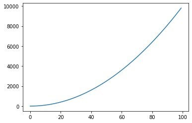

```python
plt.plot(x, y)
```

```python
points = np.random.multivariate_normal([13, 7], [[2, 6], [6, 20]], size=1000) # 2d gauss
points
```

```
array([[10.71567441,  0.04668416],
       [15.12399541, 13.98834262],
       [14.40371218, 10.28124693],
       ...,
       [10.55755199,  1.44327486],
       [14.4343159 , 11.38945638],
       [14.86837238, 13.24587216]])
```

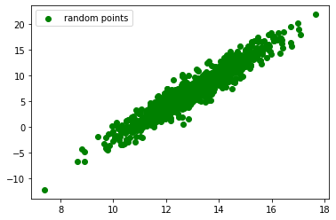

```python
x = points.T[0]
y = points.T[1]
plt.scatter(x, y, color='g', label='random points')
plt.legend()
```

matplotlib има широка функционалност, но за по-сложни графики иска доста писане и експлицитно задаване на параметри. Затова е много по-лесно да изпозлваме seaborn, където голяма част от този допълнителен год е вече написан от някого другиго. Например, ако искаме да направим графика на линейна регресия, това става с един ред на seaborn:

```python
data = pd.DataFrame(points, columns=['x', 'y']) # така създаваме pandas.DataFrame от numpy масиви (можем и направо от обикновенни python листове)
data
```

|  | x | y |
| --- | --- | --- |
| 0 | 10.715674 | 0.046684 |
| 1 | 15.123995 | 13.988343 |
| 2 | 14.403712 | 10.281247 |
| 3 | 12.334476 | 7.390546 |
| 4 | 14.046664 | 12.832049 |
| ... | ... | ... |
| 995 | 13.846339 | 8.823237 |
| 996 | 13.876260 | 9.626112 |
| 997 | 10.557552 | 1.443275 |
| 998 | 14.434316 | 11.389456 |
| 999 | 14.868372 | 13.245872 |

1000 rows × 2 columns

```python
import seaborn as sns
```

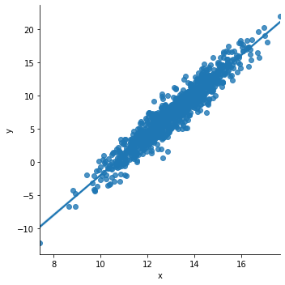

```python
sns.lmplot(x='x', y='y', data=data)
```

Виждаме, че начина на подаване на данните към seaborn прилича много повече на този в R (подаваме само имената на колоните и отделно DataFrame с данните, от които да се вземат тези колони) отколкото този при matplotlib. Понеже данните са генерирани от гаусово разпределение, имаме почти перфектен фит на правата. Ако вкараме допълнителна грашка, ще видим, че seaborn я репрезентира автоматично без ние да правим нищо допълнително

```python
data['y'] += 70 * np.random.random(len(data))
```

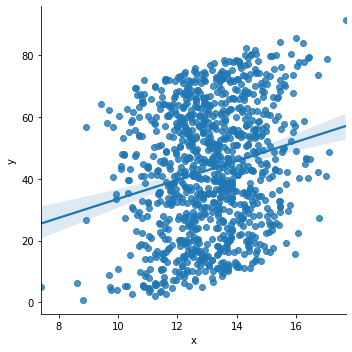

```python
sns.lmplot(x='x', y='y', data=data, palette=['red'])
```

Това е само графична репрезентация на линеен фит на точките. За да свикнем с изпозлването на python за статистически анализ, в следващото упражнение ще разгледаме проста линейна регресия чрез библитеката statsmodels.